# Measures of Central Tendency and Central Limit Theorem

## Measures of Central Tendency

In most experiments conducted in science and associated research, we note certain occurence of events and facts associated with the events or objects involved in it. This quantified or qualified information we document are often called **'observations'**.

For any event or system, there are certain inputs/conditions which affect the way the event ends or the way the system acts. What we observe at the end of the experiment can be called an **'output'**. Observing a certain output may be dependent upon the type of conditions maintained during the event, or in other words, the **'inputs'** given to the system.

When the experiment is repeated by observing these specific conditions in order to collect an output observation each time, we get a series of observations. For various combinations of inputs we may get various outputs. If the system gives the same output, under any combination of inputs, then it would be a definitive system, with no uncertainty in the type of output that we could see.

However, when the observation value changes each time the experiment is repeated, then the series of observations we have record would have a **'variance'** in them. These observations when plotted on a coordinate system would be spread across, due to the variation in values. This is called as a **'distribution'**.

Distributions are often studied by plotting all the observations on coordinate axes. One common observation in many real life experiments is that when these observations are divided in buckets, some buckets tend to have a lot more observations than others. That is, there is higher concentration of observations around a specific value. Lets look at an example to understand more.

Observe the heights of all individuals (full grown, adults) in this world. If we plot all the individual heights, we may possibly get a range with lowest value around 2 feet and heighest value around 8 or 9 feet depending upon the height of the tallest known man. Now, it is rare for us to find adults who are 2 or 3 feet tall and also rare for us to find someone who is 7 feet or taller. These are extermities and don't occur too often. The more commonly observed individuals are between 5 feet and 6 feet mark.

Given we randomly pick 100 inviduals from anywhere in the world, the average height of these individuals may probably fall between 5 feet and 6 feet. Hence if the mean lies between 5 and 6 feet mark, then the density of observations is generally higher around this mark. It is for this reason that any such metric which tries to identify a commonly occurring observation value is called **"a measure of central tendency"**. This denotes that this average value is referred to as a normal value and most observations tend to be around this, making it the center. Hence, it is called central tendency.

### Mean

Mean, or average, is one of the measures of central tendency. It is one of the most common measures of central tendency. If for an experiment $A$, I have the following set of observations $a_1, a_2, a_3...a_n$, then the average of sample space of $A$ is given by $\bar{a}$ as:

## $\bar{a} = \frac{\sum_{i=1}^{n}a}{n}$

Here, $\bar{a}$ is called sample mean, whereas population mean is denoted by '$\mu$'.

Mean of an array of numbers can be calculated in python using the 'np.mean()' function from numpy.

Example:

```
import numpy as np

a = np.array([1,2,3,4,5,6,7])

np.mean(a)

# Output
>>> 4.0
```

Now we will define a group and utilize the same group to explain mean and other measures of central tendency, so it is easy to perceive and differentiate between the various measures.

Assume that we are measuring heights of 10 people. Their names and heights are as follows:

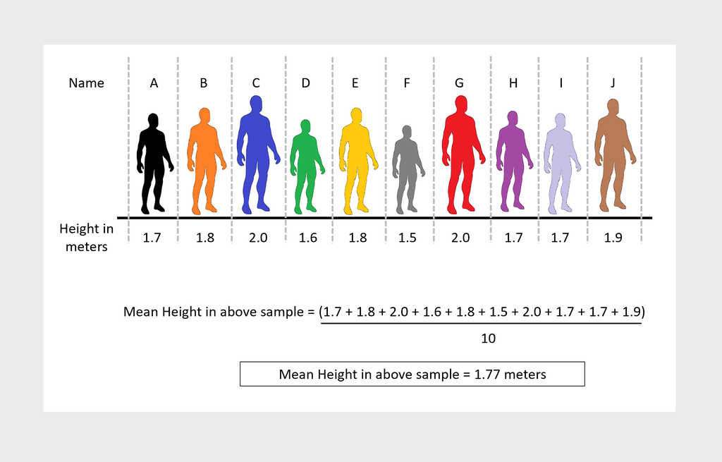

Let us now try to use a python function to verify above calculation

#### Exercise

Given above heights, use numpy's mean function to calculate average height of the above sample.

### Solution code

```
import numpy as np

a = np.array([1.7, 1.8, 2.0, 1.6, 1.8, 1.5, 2.0, 1.7, 1.7, 1.9])

np.mean(a)
```

### Median

The median is another measure of central tendency. In order to calculate the median of a sample, all the observations are required to be arranged in increasing or decreasing order of magnitude. Once all observations are arranged in an order, the observation in the middle of the sample, which splits the sample into equal halves is the "median" of the sample. Here, if the sample has an odd number of observations, then the observation in the middle, the median, would have equal number of observations which would be less than it in magnitude and equal observations which would be greater than it in magnitude. If there are even number of observations in the sample, then the median would be the average of the two middle values (as there would not be one single middle value in case of even number of observations, See below example to understand).

Taking the example of a sample set of people and their heights, the median in the example used earlier would be as follows:

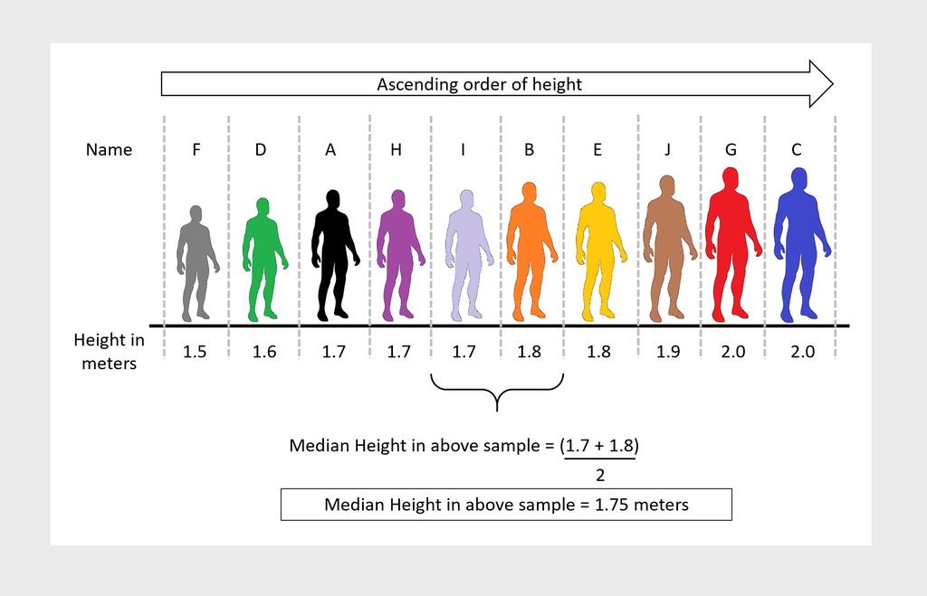

Example:

```
import numpy as np

a = np.array([1,2,3,4,5,6,7])
b = np.array([1,2,3,4,5,6,7,8])

print(np.mean(a),np.mean(b))

# Output
>>> 4.0 4.5
```

#### Exercise

Now calculate the median for above sample of 10 people and their height and verify if the median of the sample is the same as calculated in the image given in the above section.

### Solution code

```
import numpy as np

a = np.array([1.7, 1.8, 2.0, 1.6, 1.8, 1.5, 2.0, 1.7, 1.7, 1.9])

np.median(a)
```

### Mode

The mode of a sample of observations is nothing but the most frequent observation among the set of observations. This specific measure of central tendency assumes that the observation which has been repeated the most number of times has higher probability of occurring again and hence holds the property of central tendency of observations.

A distribution which has a single element as the highest repeating observation is called a 'unimodal distribution'. If there are two values which have repeated equally frequently, then such a distribution is called a 'bimodal distribution' and so on.

Going back to the example of a sample set of people and their heights, the mode in the example used earlier would be as follows:

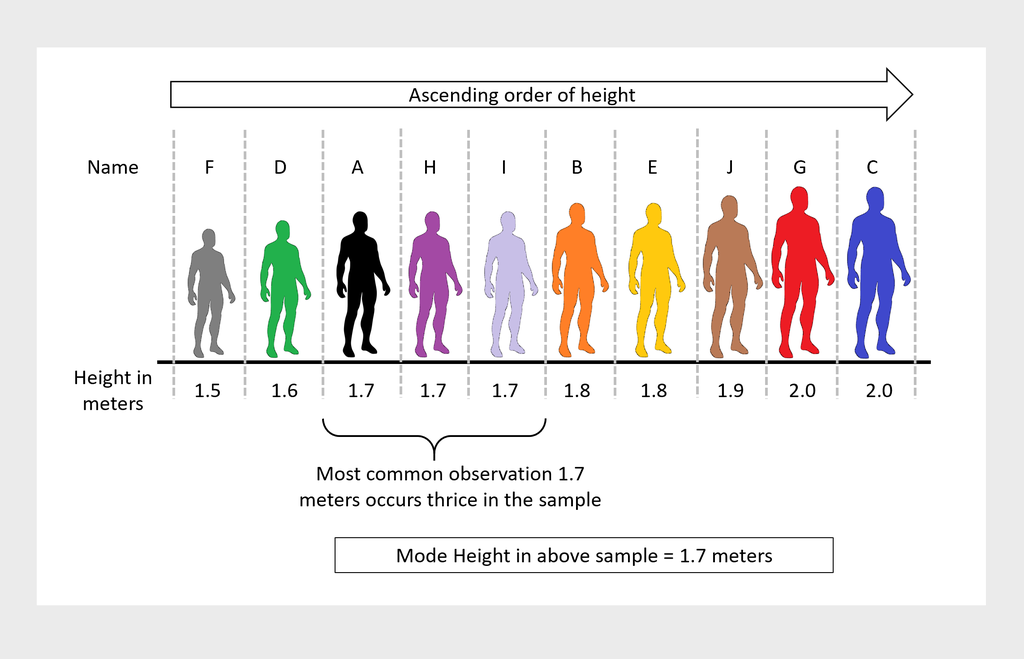

We can calculate mode of a sample by using stats module's mode function. Stats is a module in the Scipy package.

Example:

```
from scipy import stats

a = np.array([1,2,3,4,2,3,6,2,1,3,5,7,4,2,2,4,3,2,4,7,8,4,2,5,1,6])

print(stats.mode(a))

# Output
>>> ModeResult(mode=array([2]), count=array([7]))
```

The above output states that mode is '2' (in the output it is depicted as the array with single element 2. In case of bimodal distribution this array would have 2 elements) and count is '7', i.e. 2 repeats as an observation for 7 times (this is again an array as it would have more frequency counts in case of multiple modes).

#### Exercise

Calculate the mode for above sample of 10 people and their height and verify if the mode of the sample is the same as calculated in the image given in the above section.

### Solution code

```
from scipy import stats

a = np.array([1.7, 1.8, 2.0, 1.6, 1.8, 1.5, 2.0, 1.7, 1.7, 1.9])

print(stats.mode(a))
```

### Why and When?

#### Why do we have 3 different measures of central tendency? Which one is the best?

There exist these 3 different measures of central tendency because no single measure of tendency is good in all scenarios. Depending upon the type of data we are dealing with and the objective of our data analysis, we are required to use different measures of central tendency. Hence, there is no single best measure of tendency.

#### When do we use each of the measures discussed above?

The mean, median and mode, each have their own pros and cons. An interesting point to observe is that:

- The Mean of a sample may or may not be the value of any real observations in the sample, as it is a calculated value.
- The Median of a sample will be one of the observations if the sample has odd number of observations and will not be any of the observations in case the sample has even number of observations.
- The Mode of a sample is always one or more of actual observations from the sample.

**Mean:** The mean is calculated using all observations of a sample. This means that 'error' (which is defined as the distance between observation and calculated sample mean) from all observations is almost always zero and hence, mean is a better measure to use in case of prediction of observation values. Also, mean is most commonly used when distributions are continuous in nature. This ensures that irrespective of what the calculated value of mean is, there is every possibility that an observation can actually have the exact value as the mean.

However, by nature of the calculation that mean emerges from, it is affected by every observation of the sample. And if the sample has extreme observations, called outliers, then the mean is significantly affected by this and may not present an appropriate representation of the data.

**Median:** The median is calculated after arranging the observations in increasing or decreasing order of magnitude, but the magnitudes themselves do not affect the position of the middle observation, which is the median. Hence, median is (almost) unaffected by outliers. It is for this reason that a median is a good measure of central tendency when the sample distribution is skewed (heavy towards one side). Median is a good measure for both discrete and continuous distributions.

**Mode:** The mode is the most frequent observation in the given sample. It is most suited for 'nominal' data. In case of continuous disctributions, it is highly unlikely to have the exact same value to repeat multiple times. Observations may be close, but not exactly of the same value. This would mean that we would have many observations close to each other and each of them may have equal frequency count to be the mode.

Another drawback with mode is that if the frequently repeated value is isolated from most other observations in the sample, then it would not be representative of the actual magnitudes of the observations. i.e., Assume that in a given sample, an outlier/extremity has the highest frequency count, it would be the mode of the sample, however it would be an inappropriate measure of central tendency in this case. It is for this reason that mode is much more appropriate for 'nominal' data.

```python
# No exercise
```

### Solution code

```
# No exercise
```

## Central Limit Theorem

The main reason why statistical analysis is conducted, is to infer properties of a population by looking at the characteristics of its samples. It is said (and proved) that if the sample size is large enough, then the sample statistics tend to be more representative of the population parameters, i.e., as the size of the sample approaches the population size, the magnitude of the sample statistics (such as mean, variance, standard deviation etc.) approach the population parameters (such as population mean, variance and standard deviation).

Now the central limit theorem states that if $\bar{x_1},\bar{x_2},\bar{x_3}...\bar{x_n}$ are sample means of $n$ different samples randomly drawn from the population, if $n$ is large enough then, the mean of $\bar{x_1},\bar{x_2},\bar{x_3}...\bar{x_n}$ (all the sample means) tends to approach the population mean $\mu$.

### Importance of Central Limit Theorem

As mentioned above, as the sample size tends to the population size, the sample mean also tends towards the population mean. However, in most real-life scenarios it is impractical to assume that we could have samples whose size would even be comparable to the population. The cost of data collection is really high and hence it would defeat the whole idea of application of any statistical model within a reasonable budget. It is for this reason, we should be able to determine the degree or extent to which the sample in hand is representative of the population. The central limit theorem, through the concept of sampling distribution tries to determine how far away a sample statistic is from its corresponding population parameter. This is measured using a score referred to as the 'Z score'.

Given,  
{$x_1,x_2,x_3...x_n$} are observations in the sample size  
$X$ is the mean of $x_1,x_2,x_3...x_n$, i.e. It is the sample mean  
$\mu$ is the population mean  
$\sigma$ is the population variance  
$n$ is the sample size, i.e. number of observations in the sample

then,  
Z-score is given by:

## $Z=\frac{X-\mu}{(\sigma/\sqrt{n})}$

The Z-score is calculated by normalizing the sampling distribution over the sample standard deviation. By normalize we mean, we relatively shrink (or grow) the distribution such that the total area under the distribution curve would be 1.

Why would we normalize the sampling distribution? We normalize because we would like to determine the **"likelihood"** that a sample actually belongs to the population and to what degree it is representative of its population. This likelihood is calculated using probability - given all possible sample statistic values in the population, what is the possibility that my current sample is similar and representative of the population distribution. As total probability value is 1, we normalize the distribution. The total area under the curve would be equivalent to the total probability (which is 1), and the **'area under the curve'**, until the position of the Z-score, would be the likelihood/probability of the sample being representative of the population. Hence, the area under the curve gives us the likelihood. This is also called as 'p-value'.

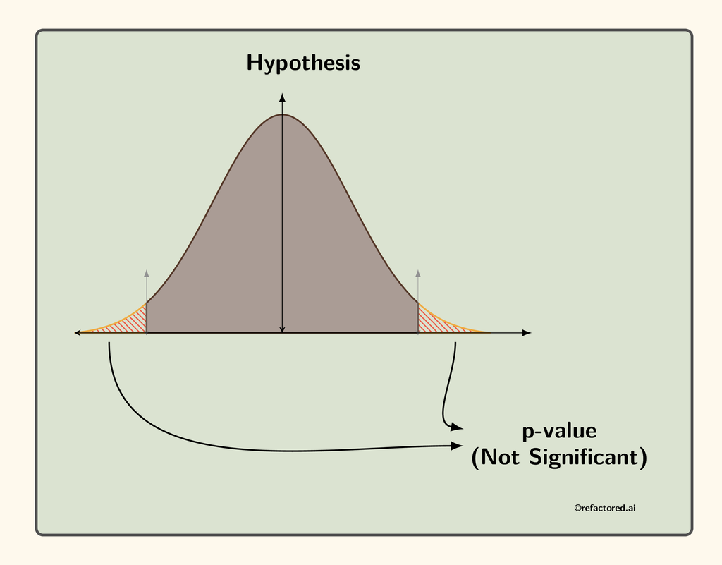

#### Run the below code

The code given below provides evidence to the concept of central limit theorem. Irrespective of the population distribution, the sampling distribution of means is always normal. Execute the code given to observe this concept in action.

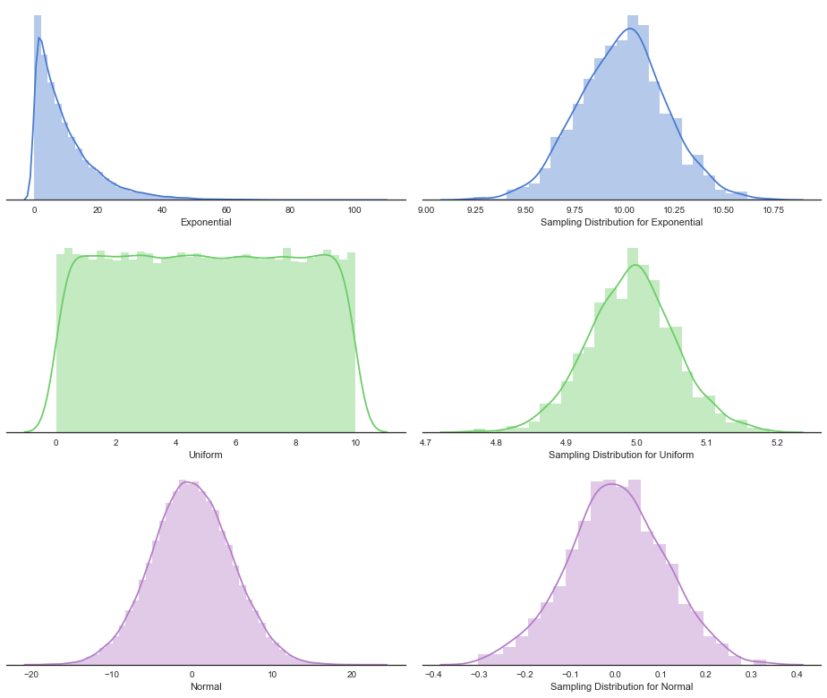

```python
# Importing all libraries and packages
from random import sample

import numpy as np
import numpy.random as nr
import seaborn as sns
import matplotlib.pyplot as plt

%matplotlib inline

# Defining function to calculate means of various random samples
def sampling_distribution(p,n,m):
    smean_dist = []
    for i in range(0,m):
        smean_dist.append(np.mean(np.array(sample(list(p),n))))
    return smean_dist


# Population a having exponential distribution
a = nr.exponential(10,50000)

# Population b having uniform distribution
b = nr.uniform(0,10,50000)

# Population c having normal distribution
c = nr.normal(0,5,50000)

# List of means of a 1000 random samples from population a
dist_1 = sampling_distribution(a,2000,1000)

# List of means of a 1000 random samples from population b
dist_2 = sampling_distribution(b,2000,1000)

# List of means of a 1000 random samples from population c
dist_3 = sampling_distribution(c,2000,1000)

# Preset for seaborn plots
sns.set(style="white", palette="muted", color_codes=True)

# Set up the matplotlib figure
f, axes = plt.subplots(3, 2, figsize=(13, 11))
sns.despine(left=True)

# Plotting distribution for population a
sns.distplot(a, color="b", ax=axes[0, 0], axlabel="Exponential")

# Plotting sampling distribution of means for various samples of a
sns.distplot(dist_1, color="b", ax=axes[0, 1], axlabel="Sampling Distribution for Exponential")

# Plotting distribution for population b
sns.distplot(b, color="g", ax=axes[1, 0], axlabel="Uniform")

# Plotting sampling distribution of means for various samples of b
sns.distplot(dist_2, color="g", ax=axes[1, 1], axlabel="Sampling Distribution for Uniform")

# Plotting distribution for population c
sns.distplot(c, color="m", ax=axes[2, 0], axlabel="Normal")

# Plotting sampling distribution of means for various samples of c
sns.distplot(dist_3, color="m", ax=axes[2, 1], axlabel="Sampling Distribution for Normal")

plt.setp(axes, yticks=[])
plt.tight_layout()
```

### Solution code

```
# Just run above code
```